# Protein *** Protocols

#### 1.2.3 Results

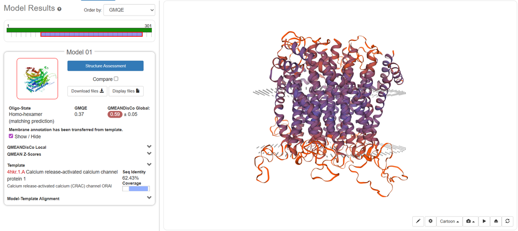

Figure 3: ORAI1 model SwissModel

Table 2: Key parameters of the homology model generated with SWISS-MODEL.

[output not shown]

Additionally, the QMEANDisCo Local Score can also be analyzed (Figure 4) to assess the per-residue confidence across the ORAI1 structure.

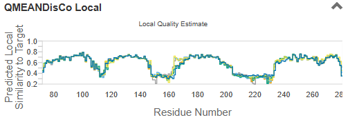

Figure 4: ORAI1 QMEANDisCo Local

### 1.3 ESMFold

https://colab.research.google.com/github/sokrypton/ColabFold/blob/main/ESMFold.ipynb#scrollTo=CcyNpAvhTX6q

#### 1.3.1 Justification of the method

ESMFold predicts the three-dimensional structure of proteins directly from their amino acid sequence using a protein language model (pLM). Unlike many other structure prediction methods, it relies on internal representations generated by a transformer-based architecture to infer interatomic distances and torsion angles, without requiring a search for evolutionary sequence alignments (MSA). As a result, the computational cost is significantly reduced.

This approach can be particularly advantageous for proteins such as ORAI1, whose flexible terminal regions and membrane-associated segments may be difficult to model using traditional homology-based methods, as language-model-based predictions can better capture structural patterns directly from sequence information.

#### 1.3.2 Methods

Due to the memory limitations (900 residue limit), a reduced oligomeric model was generated in ESMFold (trimer). Instead of modelling the full complex, a smaller multimeric assembly was used to explore whether the predicted structure could correctly reproduce the protein–protein interface and the relative orientation of the transmembrane helices. This serves as an intermediate structural validation between the monomeric model and the functional hexameric assembly obtained with the other methods.

For this reason, the sequence was analysed using three copies (`copies: 3`) and three recycling cycles (`num_recycles: 3`), which improves the refinement of inter-chain contacts while keeping the computational cost manageable.

To visualize the predicted models, the hexameric assembly was manually reconstructed by duplicating the predicted trimer and positioning it to form the full complex.

#### 1.3.3 Results

ESMFold provides a confidence plot (Figure 5) composed of three complementary panels that allow evaluation of both the structural reliability and the predicted inter-chain interactions.

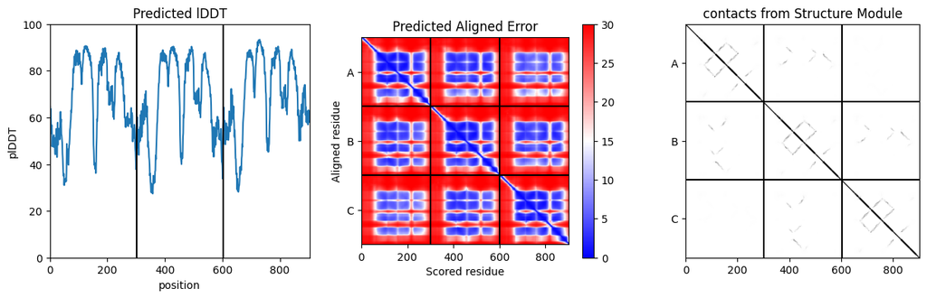

Figure 5: ORAI1 Confidence Plot